# ToothGrowth

Cyril Medabalimi

September 27, 2015

## Loading and Summary of the Data

The table below shows the view of the top 10 values

| len | supp | dose |
| --- | --- | --- |
| 4.2 | VC | 0.5 |
| 11.5 | VC | 0.5 |
| 7.3 | VC | 0.5 |
| 5.8 | VC | 0.5 |
| 6.4 | VC | 0.5 |
| 10.0 | VC | 0.5 |
| 11.2 | VC | 0.5 |
| 11.2 | VC | 0.5 |
| 5.2 | VC | 0.5 |
| 7.0 | VC | 0.5 |

The table below shows a summary of the three variables

|  | len | supp | dose |
| --- | --- | --- | --- |
|  | Min. : 4.20 | OJ:30 | Min. :0.500 |
|  | 1st Qu.:13.07 | VC:30 | 1st Qu.:0.500 |
|  | Median :19.25 | NA | Median :1.000 |
|  | Mean :18.81 | NA | Mean :1.167 |
|  | 3rd Qu.:25.27 | NA | 3rd Qu.:2.000 |
|  | Max. :33.90 | NA | Max. :2.000 |

The figure below shows a box plot of the length of tooth by supplement and dosage. We observe that the higher the dosage the longer the tooth was. As the graph shows the median of the 2mg dosage was similar for both supplements.

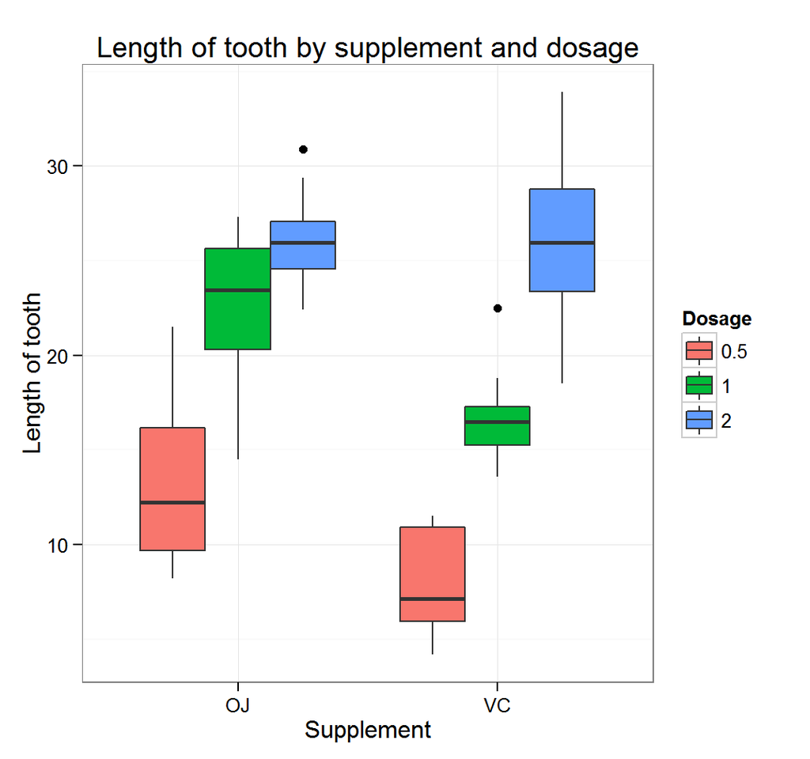

```r
g <- ggplot(tooth_data, aes(x=supp, y=len)) + geom_boxplot(aes(x=supp, y=len,fill =factor(dose))) + labs(title="Length of tooth by supplement and dosage",
                                                                                                     y="Length of tooth", x="Supplement") +
  guides(fill=guide_legend(title="Dosage")) + theme_bw()
print(g)
```

## Analysis of the data

Below we calculate the mean, SD and 95% CI /(confidence interval/) for each dosage per supplement. We calculate the CI for the t-distribution of the data.The table below shows the summary where *mean*, *count* , *se* , *sd* and *ci* is the mean , count, standard error, standard deviation and the CI of tooth length respectively.

| dose | supp | count | mean | sd | se | ci |
| --- | --- | --- | --- | --- | --- | --- |
| 0.5 | OJ | 10 | 13.23 | 4.459708 | 1.4102837 | 3.190283 |
| 0.5 | VC | 10 | 7.98 | 2.746634 | 0.8685620 | 1.964824 |
| 1.0 | OJ | 10 | 22.70 | 3.910953 | 1.2367520 | 2.797727 |
| 1.0 | VC | 10 | 16.77 | 2.515309 | 0.7954104 | 1.799343 |
| 2.0 | OJ | 10 | 26.06 | 2.655058 | 0.8396031 | 1.899314 |
| 2.0 | VC | 10 | 26.14 | 4.797731 | 1.5171757 | 3.432090 |

The graph below shows the length with the error bars or CI included. The bar graph has the the standard error shown for range shown for each dosage per supplement. The line graph shows the CI for each supplement. We observe there is an overlap of the CI for 2mg dosage. The other shows a reduction in the mean of tooth length for VC supplement.

```
## ymax not defined: adjusting position using y instead
## ymax not defined: adjusting position using y instead
```

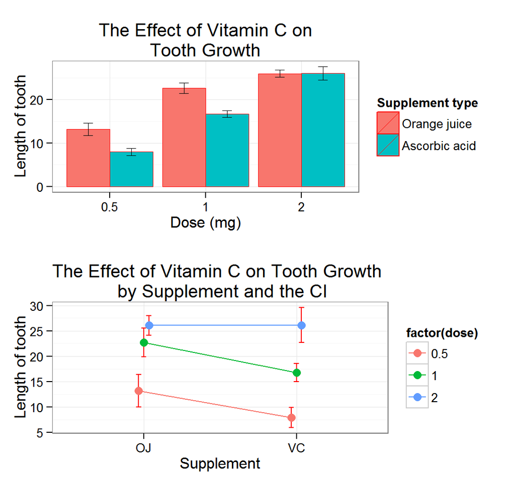

Finaly we do a ttest to confirm whether there is a significance difference between the means of VC and OJ supplement per dosage.

The results of the test for showed that there was no significance difference in tooth length for **orange juice(OJ)** and **ascorbic acid(VC)** supplements without considering the dosage. The *pvalue* was 0.0603934 and the *95% confidence interval* was -0.1670064, 7.5670064 . We decided to do a test per dosage between the groups

## **0.5mg Dosage Test**

There was a significance differnce between the means of the 0.5mg **OJ** and **VC**. The reported *pvalue* was 0.0053037 and the *95% confidence interval* was 1.7702617, 8.7297383. The 0.5mg VC dosage had a mean of 7.98 which was lower than the OJ dosage mean. This concludes that Orange Juice had a higher effect on the tooth length for the 0.5mg dosage compared to ascorbic acid.